# Getting started with R

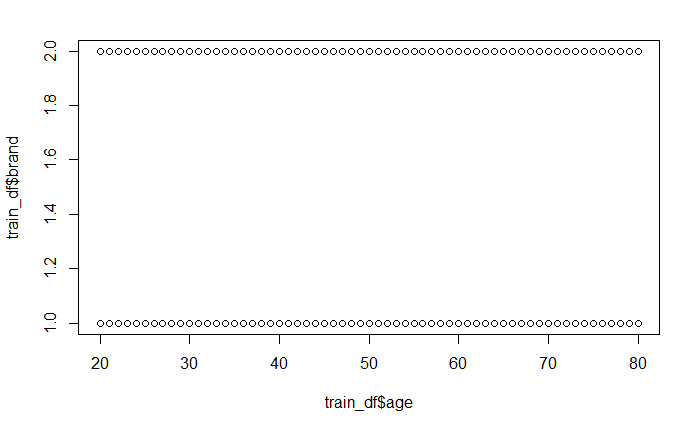

```r
plot(train_df$age,train_df$brand)
```

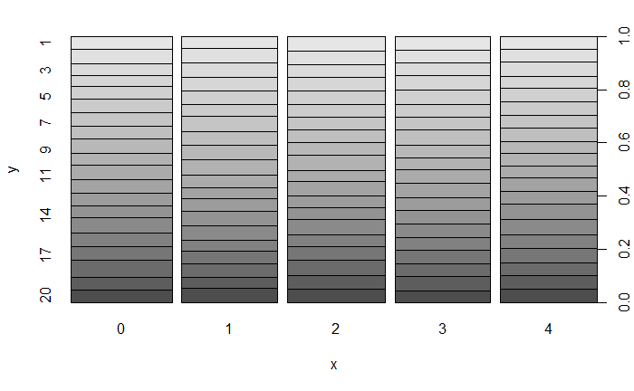

```r
plot(train_df$elevel,train_df$car)
```

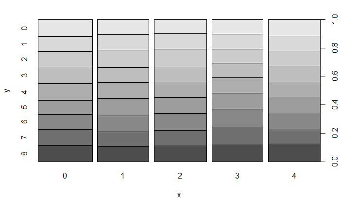

```r
plot(train_df$elevel,train_df$zipcode)
```

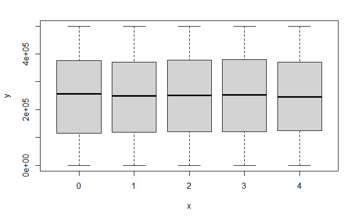

```r
plot(train_df$elevel,train_df$credit)
```

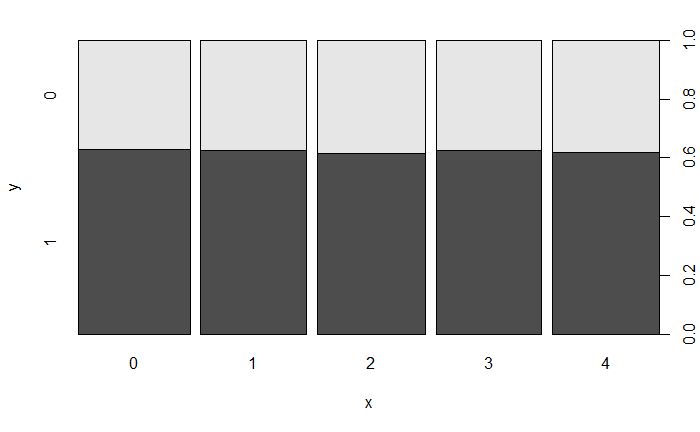

```r
plot(train_df$elevel,train_df$brand)
```

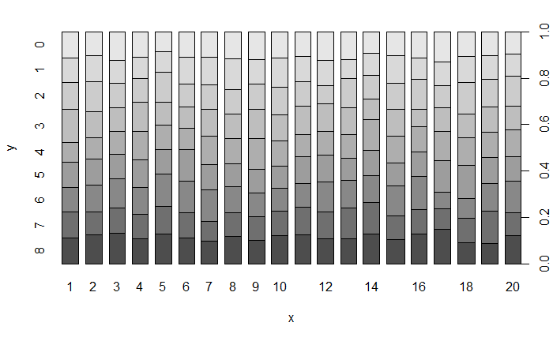

```r
plot(train_df$car,train_df$zipcode)
```

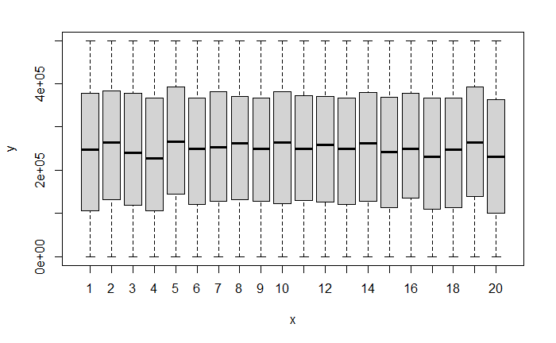

```r
plot(train_df$car,train_df$credit)
```

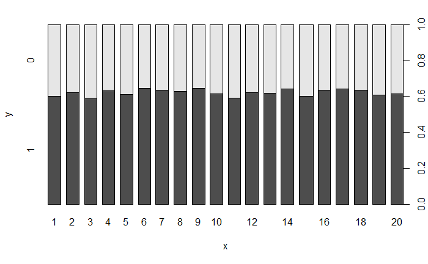

```r
plot(train_df$car,train_df$brand)
```

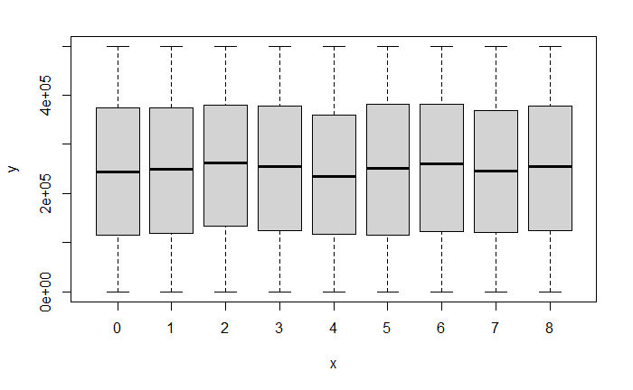

```r
plot(train_df$zipcode,train_df$credit)
```

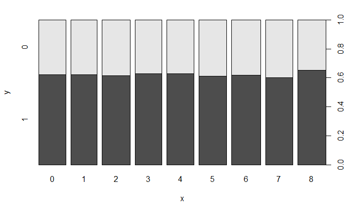

```r
plot(train_df$zipcode,train_df$brand)
```

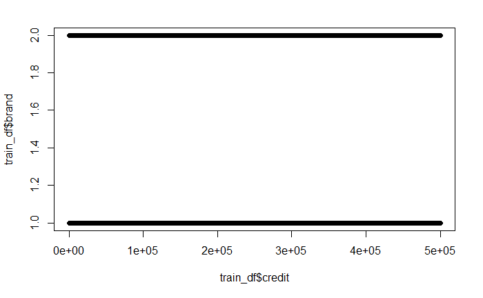

```r
plot(train_df$credit,train_df$brand)
```

None of the graphs above seem useful whatsoever..

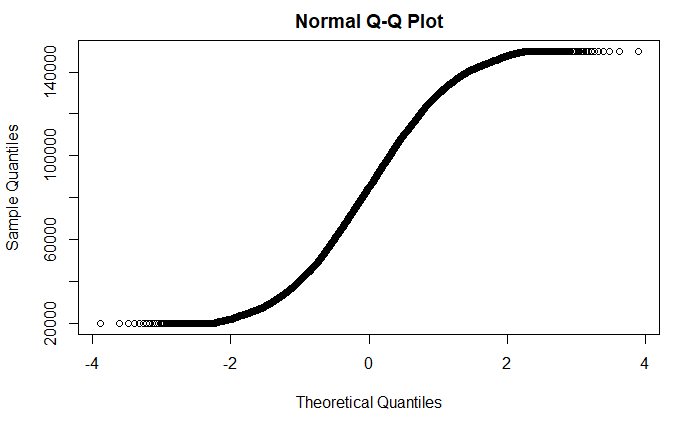

```r
qqnorm(train_df$salary)
```

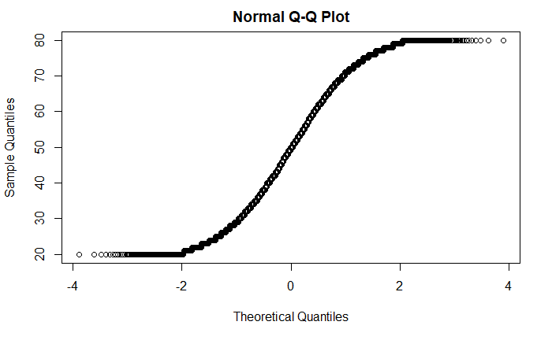

```r
qqnorm(train_df$age)
```

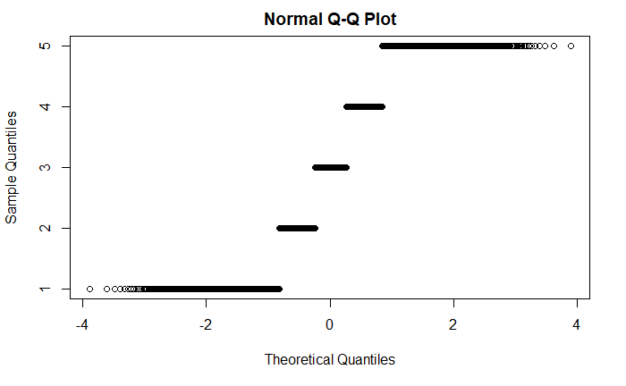

```r
qqnorm(as.integer(train_df$elevel))
```

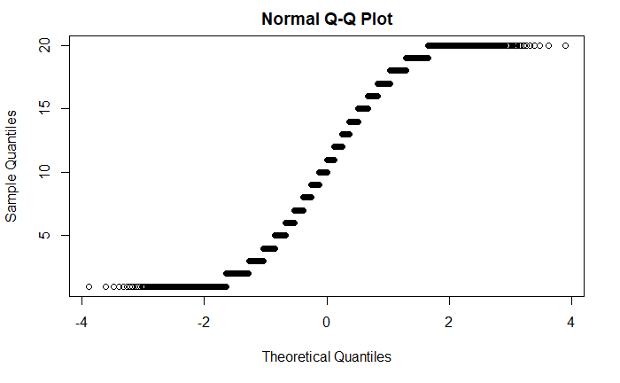

```r
qqnorm(as.integer(train_df$car))
```

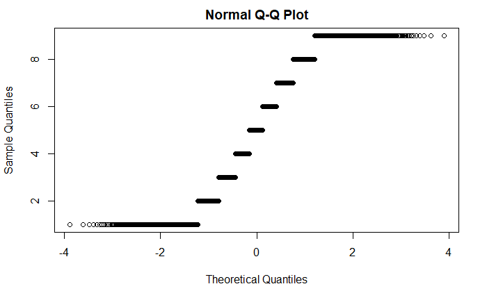

```r
qqnorm(as.integer(train_df$zipcode))
```

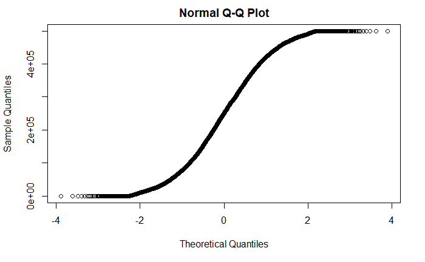

```r
qqnorm(train_df$credit)
```

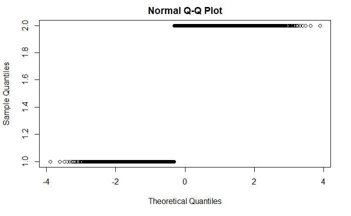

```r
qqnorm(as.integer(train_df$brand))
```

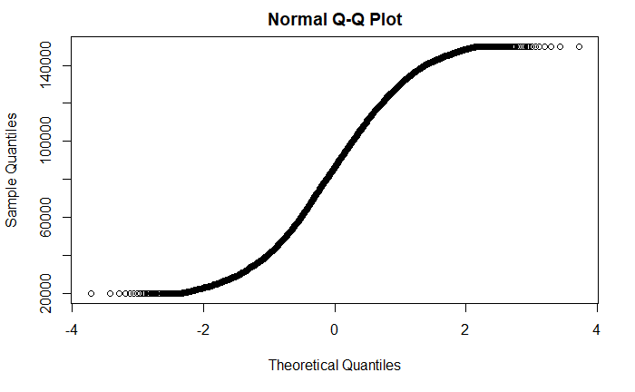

```r
qqnorm(test_df$salary)
```

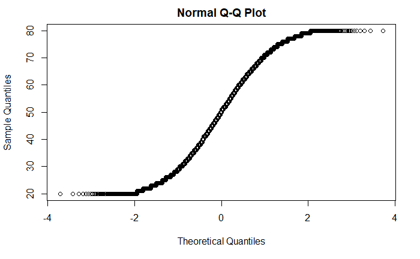

```r
qqnorm(test_df$age)
```

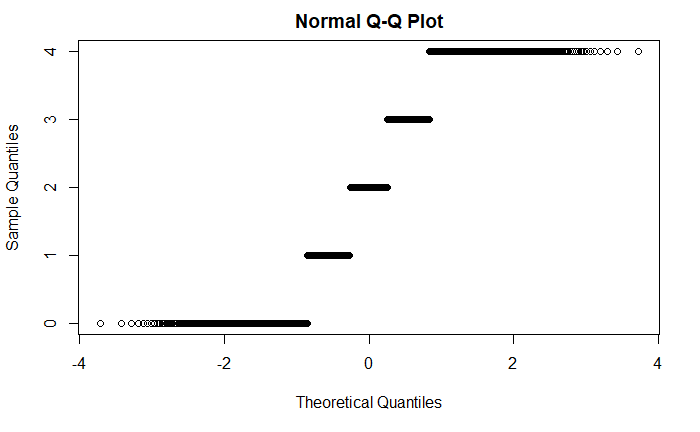

```r
qqnorm(as.integer(test_df$elevel))
```

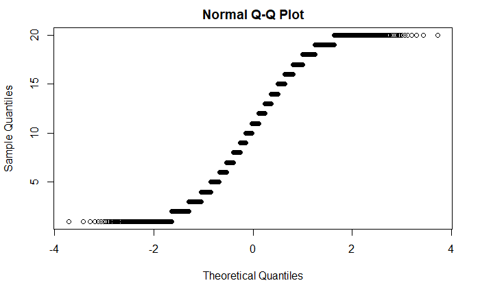

```r
qqnorm(as.integer(test_df$car))
```

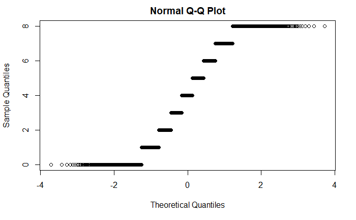

```r
qqnorm(as.integer(test_df$zipcode))
```

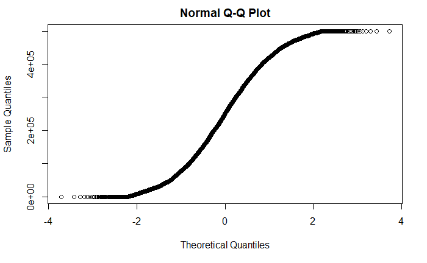

```r
qqnorm(test_df$credit)
```

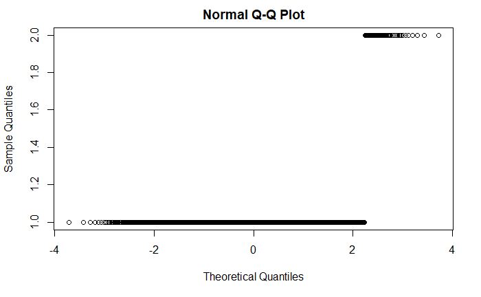

```r
qqnorm(as.integer(test_df$brand))
```

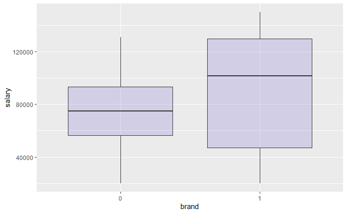

```r
ggplot(train_df, aes(x=as.factor(brand), y=salary)) +
    geom_boxplot(fill="slateblue", alpha=0.2) +
    xlab("brand")
```

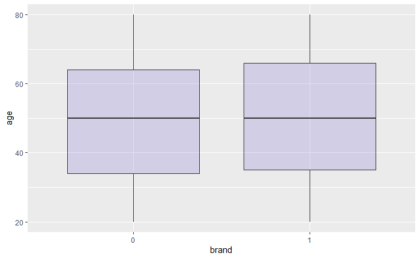

```r
ggplot(train_df, aes(x=as.factor(brand), y=age)) +
    geom_boxplot(fill="slateblue", alpha=0.2) +
    xlab("brand")
```

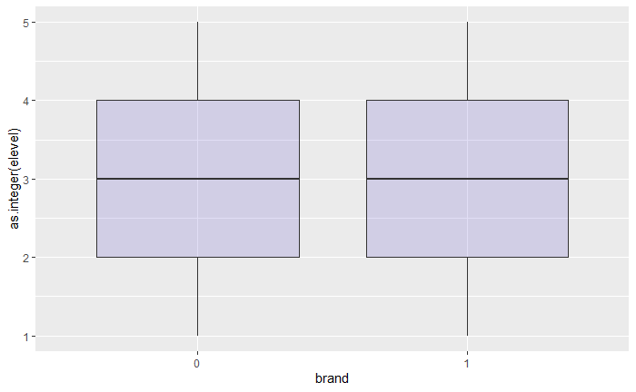

```r
ggplot(train_df, aes(x=as.factor(brand), y=as.integer(elevel))) +
    geom_boxplot(fill="slateblue", alpha=0.2) +
    xlab("brand")
```

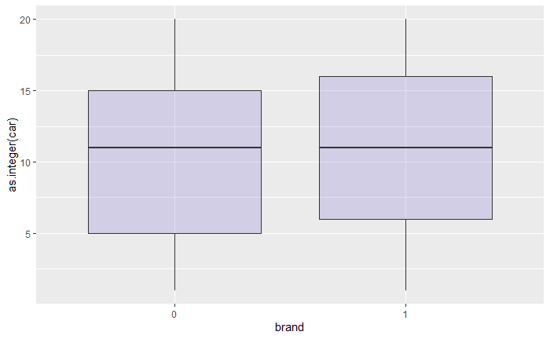

```r
ggplot(train_df, aes(x=as.factor(brand), y=as.integer(car))) +
    geom_boxplot(fill="slateblue", alpha=0.2) +
    xlab("brand")
```

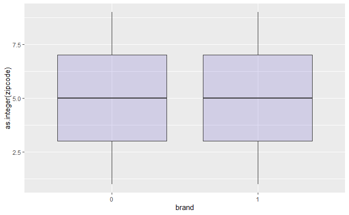

```r
ggplot(train_df, aes(x=as.factor(brand), y=as.integer(zipcode))) +
    geom_boxplot(fill="slateblue", alpha=0.2) +
    xlab("brand")
```

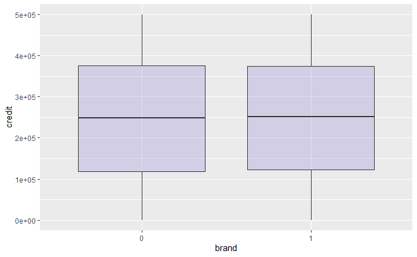

```r
ggplot(train_df, aes(x=as.factor(brand), y=credit)) +
    geom_boxplot(fill="slateblue", alpha=0.2) +
    xlab("brand")
```

The boxplots of each variable seem to be quite similar for any of the brands except in the salary’s case, this might be the most revealing feature.

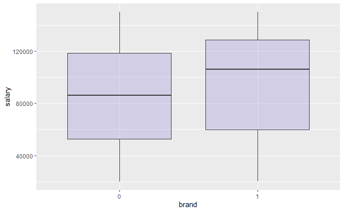

```r
ggplot(test_df, aes(x=as.factor(brand), y=salary)) +
    geom_boxplot(fill="slateblue", alpha=0.2) +
    xlab("brand")
```

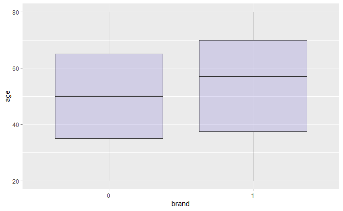

```r
ggplot(test_df, aes(x=as.factor(brand), y=age)) +
    geom_boxplot(fill="slateblue", alpha=0.2) +
    xlab("brand")
```

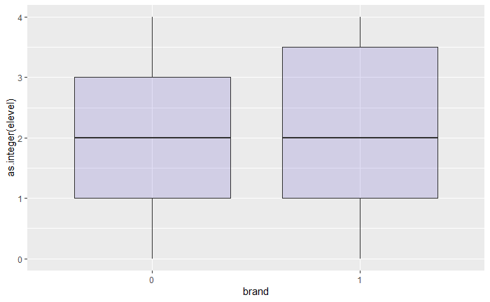

```r
ggplot(test_df, aes(x=as.factor(brand), y=as.integer(elevel))) +
    geom_boxplot(fill="slateblue", alpha=0.2) +
    xlab("brand")
```

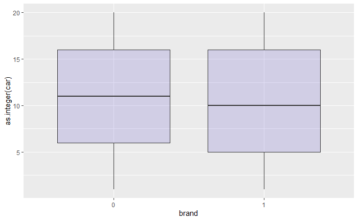

```r
ggplot(test_df, aes(x=as.factor(brand), y=as.integer(car))) +
    geom_boxplot(fill="slateblue", alpha=0.2) +
    xlab("brand")
```

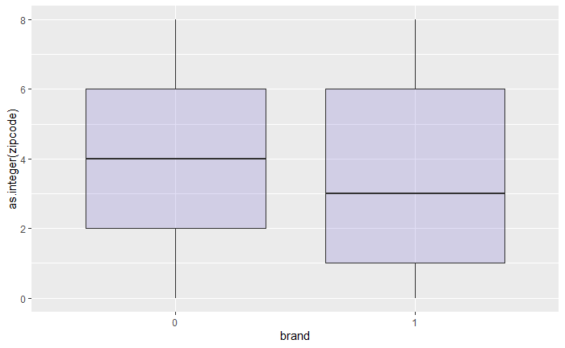

```r
ggplot(test_df, aes(x=as.factor(brand), y=as.integer(zipcode))) +
    geom_boxplot(fill="slateblue", alpha=0.2) +
    xlab("brand")
```

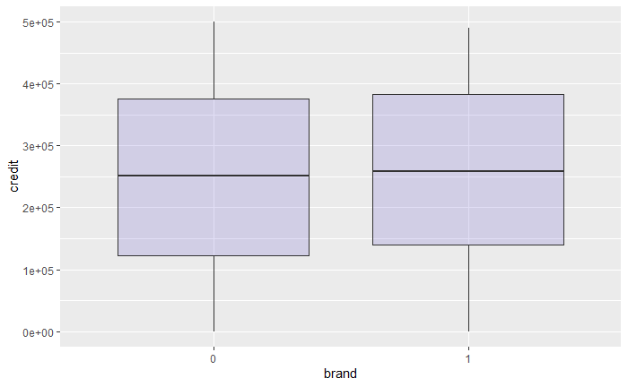

```r
ggplot(test_df, aes(x=as.factor(brand), y=credit)) +
    geom_boxplot(fill="slateblue", alpha=0.2) +
    xlab("brand")
```

Both salary and age features have quite different boxplots for each brand, these two features seem to be the most relevant to forecast the brand in the test dataset.

In conclusion, it seems that both datasets have quite similar characteristics and the model trained in the train dataset will be useful in forecasting the same feature of the test dataset.

*Creating testing and training sets with caret:*

```r
OneHot_train_df <- data.frame(model.matrix( ~ ., data=train_df))
colnames(OneHot_train_df)[colnames(OneHot_train_df) == 'brand1'] <- 'brand'

OneHot_train_df$brand <- as.factor(OneHot_train_df$brand) #Reconvert brand into binary column not integer.

OneHot_train_df
```

|  | X.Intercept. | salary | age | elevel1 | elevel2 | elevel3 | elevel4 | car2 | car3 | car4 | car5 | car6 | car7 | car8 | car9 | car10 | car11 | car12 | car13 | car14 | car15 | car16 | car17 | car18 | car19 | car20 | zipcode1 | zipcode2 | zipcode3 | … |
| --- | --- | --- | --- | --- | --- | --- | --- | --- | --- | --- | --- | --- | --- | --- | --- | --- | --- | --- | --- | --- | --- | --- | --- | --- | --- | --- | --- | --- | --- | --- |
| 1 | 1 | 119806.54 | 45 | 0 | 0 | 0 | 0 | 0 | 0 | 0 | 0 | 0 | 0 | 0 | 0 | 0 | 0 | 0 | 0 | 1 | 0 | 0 | 0 | 0 | 0 | 0 | 0 | 0 | 0 | … |
| 2 | 1 | 106880.48 | 63 | 1 | 0 | 0 | 0 | 0 | 0 | 0 | 0 | 0 | 0 | 0 | 0 | 0 | 1 | 0 | 0 | 0 | 0 | 0 | 0 | 0 | 0 | 0 | 0 | 0 | 0 | … |
| 3 | 1 | 78020.75 | 23 | 0 | 0 | 0 | 0 | 0 | 0 | 0 | 0 | 0 | 0 | 0 | 0 | 0 | 0 | 0 | 0 | 0 | 1 | 0 | 0 | 0 | 0 | 0 | 0 | 1 | 0 | … |
| 4 | 1 | 63689.94 | 51 | 0 | 0 | 1 | 0 | 0 | 0 | 0 | 0 | 1 | 0 | 0 | 0 | 0 | 0 | 0 | 0 | 0 | 0 | 0 | 0 | 0 | 0 | 0 | 0 | 0 | 0 | … |
| 5 | 1 | 50873.62 | 20 | 0 | 0 | 1 | 0 | 0 | 0 | 0 | 0 | 0 | 0 | 0 | 0 | 0 | 0 | 0 | 0 | 1 | 0 | 0 | 0 | 0 | 0 | 0 | 0 | 0 | 0 | … |
| 6 | 1 | 130812.74 | 56 | 0 | 0 | 1 | 0 | 0 | 0 | 0 | 0 | 0 | 0 | 0 | 0 | 0 | 0 | 0 | 0 | 1 | 0 | 0 | 0 | 0 | 0 | 0 | 0 | 0 | 1 | … |
| 7 | 1 | 136459.34 | 24 | 0 | 0 | 0 | 1 | 0 | 0 | 0 | 0 | 0 | 0 | 1 | 0 | 0 | 0 | 0 | 0 | 0 | 0 | 0 | 0 | 0 | 0 | 0 | 0 | 0 | 0 | … |
| 8 | 1 | 103866.90 | 62 | 0 | 0 | 1 | 0 | 0 | 1 | 0 | 0 | 0 | 0 | 0 | 0 | 0 | 0 | 0 | 0 | 0 | 0 | 0 | 0 | 0 | 0 | 0 | 0 | 0 | 0 | … |
| 9 | 1 | 72298.80 | 29 | 0 | 0 | 0 | 1 | 0 | 0 | 0 | 0 | 0 | 0 | 0 | 0 | 0 | 0 | 0 | 0 | 0 | 0 | 0 | 1 | 0 | 0 | 0 | 0 | 0 | 0 | … |
| 10 | 1 | 37803.33 | 41 | 1 | 0 | 0 | 0 | 0 | 0 | 0 | 1 | 0 | 0 | 0 | 0 | 0 | 0 | 0 | 0 | 0 | 0 | 0 | 0 | 0 | 0 | 0 | 0 | 0 | 0 | … |

[output cut: 990 more lines]

From what I read caret requires (or at least performs better) with dummy features. Therefore I converted the categorical variables into dummy features but kept the target variable (brand) as it was.

```r
set.seed(107)

inTrain <- createDataPartition(y = OneHot_train_df$brand,
            ## the outcome data are needed
            p = .75,# The percentage of data in the training set should be 75%
            list = FALSE)
#The output is a set of integers for the rows of Sonar that belong in the training set.

training <- OneHot_train_df[ inTrain,] #TrainSet will contain the selected indices.
testing <- OneHot_train_df[-inTrain,] #TestSet will contain only the remaining rows that have not been selected.

nrow(training)
```

```
[1] 7424
```

```r
nrow(testing)
```

```
[1] 2474
```

```r
library(gbm)
library(Rcpp)
```

**Caret Model 1: Build a model with Stochastic Gradient Boosting GBM to predict nominal data, with 10-fold-cross-validation and Automatic tuning Grid**

```r
gbmfitControl <- trainControl(method = "repeatedcv", number = 10, repeats = 1)
```

Because this dataset is slightly imbalanced, I will attempt to train according to the kappa metric instead of accuracy. (Practically, Cohen’s kappa removes the possibility of the classifier and a random guess agreeing and measures the number of predictions it makes that cannot be explained by a random guess. Furthermore, Cohen’s kappa tries to correct the evaluation bias by taking into account the correct classification by a random guess.)

```r
# tuneLenght = 1 (trains with 1 mtry value for RandomForest)
gbmFit1 <- train(brand~., #y, target
                 data = training, #X, features
                 metric = 'Kappa', #Metric applied
                 method = "gbm", #ML algorithm
                 trControl=gbmfitControl, #Apply CV to the training
                 tuneLength = 10, # Number of levels for each tuning parameters that should be generated
                 verbose = FALSE)

gbmFit1
```

```
Stochastic Gradient Boosting

7424 samples
  35 predictor
   2 classes: '0', '1'

No pre-processing
Resampling: Cross-Validated (10 fold, repeated 1 times)
Summary of sample sizes: 6682, 6682, 6681, 6682, 6682, 6681, ...
Resampling results across tuning parameters:

  interaction.depth  n.trees  Accuracy   Kappa
   1                  50      0.7271067  0.4236359
   1                 100      0.7256244  0.4199351
   1                 150      0.7272406  0.4226192
```

[output cut: 102 more lines]

As asked, in this part we are supposed to train a model using Stochastic Gradient Boosting, GBM, on the training set with 10-fold cross-validation and an Automatic Tuning Grid, which is what is coded above.

Train function chooses the model with the largest performance value (or smallest, for mean squared error in regression models), therefore there is no need to select the best iteration of the models.

```r
varImp(gbmFit1)
```

```
gbm variable importance

  only 20 most important variables shown (out of 34)
```

|  | Overall |
| --- | --- |
| salary | 100.00000000 |
| age | 84.29518715 |
| credit | 0.56406376 |
| car19 | 0.04809472 |
| zipcode7 | 0.04166238 |
| car15 | 0.03269293 |
| zipcode1 | 0.02451527 |
| car12 | 0.01790150 |
| elevel4 | 0.01381600 |
| car8 | 0.01300440 |

[output cut: 10 more lines]

As predicted the salary variable is the most relevant in predicting the target variable. Age comes in a close second place. The remaining variables have a really low relative impact when forecasting the target.

```r
pred_GBM <- predict(gbmFit1, newdata = testing)

Prob_pred_GBM <- predict(gbmFit1, newdata = testing, type = "prob")

postResample(pred_GBM, testing$brand)
```

```
Accuracy    Kappa
0.932498 0.856289
```

```r
confusionMatrix(data = pred_GBM,
                reference = testing$brand,
                positive = "1")
```

```
Confusion Matrix and Statistics

          Reference
Prediction    0    1
         0  849   80
         1   87 1458

               Accuracy : 0.9325
                 95% CI : (0.9219, 0.9421)
    No Information Rate : 0.6217
    P-Value [Acc > NIR] : <2e-16

                  Kappa : 0.8563

 Mcnemar's Test P-Value : 0.6424

            Sensitivity : 0.9480
            Specificity : 0.9071
         Pos Pred Value : 0.9437
         Neg Pred Value : 0.9139
             Prevalence : 0.6217
         Detection Rate : 0.5893
   Detection Prevalence : 0.6245
      Balanced Accuracy : 0.9275

       'Positive' Class : 1
```

- *Kappa*: The Kappa has been explained and commented above;
- *Mcnemar’s Test P-Value*: In terms of comparing two binary classification algorithms, the test is commenting on whether the two models disagree in the same way (or not). It is not commenting on whether one model is more or less accurate or error prone than another. This is clear when we look at how the statistic is calculated. In this case we have fed a confusion matrix to the function and not a contingency table (comparing simply the number of correct vs. incorrect observations while discounting the classes);
- *Sensitivity*: Proportion of those who correctly received a positive result (class 1 - Sony) on this test out of those who actually have a positive result (TP/(TP+FN)). The value obtained for this metric is ~95% which is alright;
- *Specificity*: Proportion of those who correctly received a negative result (class 0 - Acer) on this test out of those who actually have a negative result (TN/(FP+TN)). The percentage of correctly predicted Sony is higher than Acer;
- *Pos Pred Value*: Proportion of positive results that are true positive (TP/(TP+FP));
- *Neg Pred Value*: Proportion of negative results that are true negative (TN/(TN+FN)). This model has a higher accuracy in forecasting class 1 (Sony) relatively to class 0;
- *Prevalence*: Measure of the frequency of a condition in a population at a particular point in time ((TP+FN)/Total). In this case the condition measured is the positives. As can be seen this dataset is slightly unbalanced;
- *Detection Rate*: Here the detection rate is defined as the fraction of observations who are in fact positive and are called positive by the model (TP/Total). Fortunately, this percentage is similar to the prevalence meaning that the model captured the class skewness of this dataset. If the value was too different the False Negatives would be hindering the model’s performance;
- *Detection Prevalence*: This is defined as the number of predicted positive events (both true positive and false positive) divided by the total number of predictions ((TP+FP)/Total). This value is similar to what was obtained in the prevalence metric, this indicates that the amount of false negatives is simillar to the false positives when considering the whole test dataset;
- *Balanced Accuracy*: Balanced accuracy attempts to account for the imbalance in classes ((TPR+TNR)/2 = (Sensitivity+Specificity)/2). The balanced accuracy is slightly lower than the accuracy. Nonetheless, this metric is at 92%, thus this model clearly captured the data unbalance and is not just supposing that the most frequent class is the correct one (in this case the balanced accuracy would be 50% and the accuracy would coincide with the proportion of the most frequent class relatively to the less occuring one).

```r
temp_pred_GB = factor(ifelse(pred_GBM == 1, "Y", "N"))
temp_obs_GB = factor(ifelse(testing$brand == 1, "Y", "N"))

twoClassSummary(data = data.frame(obs = temp_obs_GB, pred = temp_pred_GB, Y = Prob_pred_GBM$'1', N = Prob_pred_GBM$'0'), lev = levels(temp_pred_GB))
```

```
      ROC      Sens      Spec
0.9792052 0.9070513 0.9479844
```

```r
#For some reason, this function does not seem to provide ROC results if a binary numerical labeling is used, I had to convert '1' into 'Y' and '0' into 'N' to obtain valid results

mnLogLoss(data = data.frame(obs = temp_obs_GB, pred = temp_pred_GB, Y = Prob_pred_GBM$'1', N = Prob_pred_GBM$'0'), lev = levels(temp_pred_GB))
```

```
  logLoss
0.2178904
```

The area under the ROC curve is close to 1 meaning that the classifier is far better than a random classifier (AUC of 0.5). In fact, the AUC is close to 1, a perfect classifier. The value of the specificity and specificity seem to have swapped among themselves (the values calculated in the function above are the correct ones), thus, I will not comment these values. - *Log Loss*: Log-loss is indicative of how close the prediction probability is to the corresponding actual/true value (0 or 1 in case of binary classification). The more the predicted probability diverges from the actual value, the higher is the log-loss value. In the case of the LogLoss metric, one usual “well-known” metric is to say that 0.693 is the non-informative value. This figure is obtained by predicting p = 0.5 for any class of a binary problem. This is valid only for balanced binary problems. Because we have obtained a Log Loss of 0.218, much lower than 0.693, we can afirm that this model is clearly better than random picking and has captured the problem.

**Caret Model 2: Use Random Forest with 10-fold cross-validation to predict nominal data and manually tune 5 different mtry values**

```r
rffitControl <- trainControl(method = "repeatedcv", number = 10, repeats = 1)
```

In this task we have to manually tune 5 different values for the “mtry” parameter.The “mtry” is the number of variables randomly sampled as candidates at each split. Note that the default values are different for classification (sqrt(p) where p is number of variables in x) and regression (p/3). In this case we are foing a classification thus the default value is sqrt(36) which is 6. I started by centering center the grid search in the default value and search equidistantly on both sides (upper and lower) of this value. However, I verified that the optimal performance falls in a higher value of “mtry”.

Similarly to the model trained above, I will optimise towards the Kappa metric.

```r
rfGrid <- expand.grid(mtry=c(6,9,10,11,12))

# tuneLenght = 1 (trains with 1 mtry value for RandomForest)
rfFit1 <- train(brand~., #y, target
                data = training,#X, features
                metric = 'Kappa', #Metric applied
                method = "rf", #ML algorithm
                trControl=rffitControl, #Apply manual grid search to the training
                tuneGrid=rfGrid, #Grid parameters
                verbose = FALSE)

rfFit1
```

```
Random Forest

7424 samples
  35 predictor
   2 classes: '0', '1'

No pre-processing
Resampling: Cross-Validated (10 fold, repeated 1 times)
Summary of sample sizes: 6682, 6683, 6681, 6682, 6681, 6681, ...
Resampling results across tuning parameters:

  mtry  Accuracy   Kappa
   6    0.9048996  0.7982182
   9    0.9148668  0.8195365
  10    0.9156757  0.8212189
  11    0.9156758  0.8210959
  12    0.9174271  0.8248747

Kappa was used to select the optimal model using the largest value.
The final value used for the model was mtry = 12.
```

As asked, in this part we are supposed to train a model using Random Forest, RF, on the training set with 10-fold cross-validation and an manual Tuning Grid, which is what is coded above.

Train function chooses the model with the largest performance value (or smallest, for mean squared error in regression models), therefore there is no need to select the best iteration of the models.

```r
varImp(rfFit1)
```

```
rf variable importance

  only 20 most important variables shown (out of 34)
```

|  | Overall |
| --- | --- |
| salary | 100.0000000 |
| age | 55.1596180 |
| credit | 12.4558211 |
| elevel4 | 0.7466062 |
| elevel3 | 0.7361643 |
| elevel1 | 0.7019070 |
| elevel2 | 0.6775728 |
| zipcode3 | 0.4398635 |
| zipcode1 | 0.4370450 |
| zipcode4 | 0.4327777 |

[output cut: 10 more lines]

Similarly to the previous model, salary once again is the most relevant feature in predicting the target variable. Again, age comes in a second place. Credit has a much higher relative importance, however, it is clearly less important than the two top features. The remaining variables have a really low relative impact when forecasting the target.

```r
pred_RF <- predict(rfFit1, newdata = testing)

Prob_pred_RF <- predict(rfFit1, newdata = testing, type = "prob")

postResample(pred_RF, testing$brand)
```

```
 Accuracy     Kappa
0.9329022 0.8568197
```

```r
confusionMatrix(data = pred_RF,
                reference = testing$brand,
                positive = "1")
```

```
Confusion Matrix and Statistics

          Reference
Prediction    0    1
         0  844   74
         1   92 1464

               Accuracy : 0.9329
                 95% CI : (0.9223, 0.9424)
    No Information Rate : 0.6217
    P-Value [Acc > NIR] : <2e-16

                  Kappa : 0.8568

 Mcnemar's Test P-Value : 0.187

            Sensitivity : 0.9519
            Specificity : 0.9017
         Pos Pred Value : 0.9409
         Neg Pred Value : 0.9194
             Prevalence : 0.6217
         Detection Rate : 0.5918
   Detection Prevalence : 0.6289
      Balanced Accuracy : 0.9268

       'Positive' Class : 1
```

Similarly to the previous model, the confusion matrix is quite solid, the auxiliary statistical metrics derived, seem to confirm so. The two models created in this exercise are quite similar in theory and in the provided results. Therefore, instead of repeating the comment section I have written for the previous model, I will just say that those comments can be applied to this model and move on to the next part (Additionaly, this model is slightly inferior relatively to the GBM thus I chose to focus in the other).

```r
temp_pred_RF = factor(ifelse(pred_RF == 1, "Y", "N"))
temp_obs_RF = factor(ifelse(testing$brand == 1, "Y", "N"))

twoClassSummary(data = data.frame(obs = temp_obs_RF, pred = temp_pred_RF, Y = Prob_pred_RF$'1', N = Prob_pred_RF$'0'), lev = levels(temp_pred_RF))
```

```
      ROC      Sens      Spec
0.9803500 0.9017094 0.9518856
```

```r
#For some reason, this function does not seem to provide ROC results if a binary numerical labeling is used, I had to convert '1' into 'Y' and '0' into 'N' to obtain valid results


mnLogLoss(data = data.frame(obs = temp_obs_RF, pred = temp_pred_RF, Y = Prob_pred_RF$'1', N = Prob_pred_RF$'0'), lev = levels(temp_pred_RF))
```

```
  logLoss
0.2105413
```

*Compare the results from two models:*

```r
results <- resamples(list(GBMAut=gbmFit1, RFMan=rfFit1))

summary(results)
```

```
Call:
summary.resamples(object = results)

Models: GBMAut, RFMan
Number of resamples: 10

Accuracy
            Min.   1st Qu.    Median      Mean   3rd Qu.      Max. NA's
GBMAut 0.9097035 0.9144205 0.9232341 0.9228169 0.9296062 0.9367429    0
RFMan  0.8962264 0.9144794 0.9205387 0.9174271 0.9219381 0.9339623    0

Kappa
            Min.   1st Qu.    Median      Mean   3rd Qu.      Max. NA's
GBMAut 0.8077111 0.8193261 0.8372952 0.8363888 0.8508848 0.8661574    0
RFMan  0.7817497 0.8185370 0.8309742 0.8248747 0.8347179 0.8593708    0
```

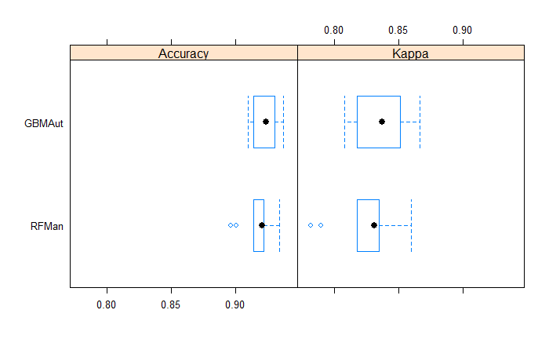

```r
bwplot(results)
```

Looking at the table and boxplot of the chunk above it seems that both algorithms have a good performance in forecasting the target of this problem. However, the Stochastic Gradient Boost seems to provide a slightly better performing model as the interquartile range for both the accuracy and kappa falls is located at a higher value.

*Forecast testing dataset with the best performing model (GBM)*